# House Sales in King County (Ceteris Paribus)

## House Sales in King County - Ceteris Paribus explanations

### Author: Piotr Grabysz

### Date: 2021-04-16

The goal of this notebook is to learn Ceteris Paribus (Latin phrase meaning "other things equal") techniques.

I use House Sales in King County dateset and try to predict house's price based upon following features

- bedrooms - Number of bedrooms
- bathrooms - Number of bathrooms, where .5 accounts for a room with a toilet but no shower
- sqft_living - Square footage of the apartments interior living space
- sqft_lot - Square footage of the land space
- floors - Number of floors
- waterfront - A dummy variable for whether the apartment was overlooking the waterfront or not
- view - An index from 0 to 4 of how good the view of the property was
- condition - An index from 1 to 5 on the condition of the apartment,
- grade - An index from 1 to 13, where 1-3 falls short of building construction and design, 7 has an average level of construction and design, and 11-13 have a high quality level of construction and design.
- sqft_above - The square footage of the interior housing space that is above ground level
- sqft_basement - The square footage of the interior housing space that is below ground level
- yr_built - The year the house was initially built
- yr_renovated - The year of the house’s last renovation
- zipcode - What zipcode area the house is in
- lat - Lattitude
- long - Longitude
- sqft_living15 - The square footage of interior housing living space for the nearest 15 neighbors
- sqft_lot15 - The square footage of the land lots of the nearest 15 neighbors

## The analysis

I choose three houses to perform the analysis on them (the same as in the previous notebooks):

|  | price | bedrooms | bathrooms | sqft_living | sqft_lot | floors | waterfront | view | condition | grade | sqft_above | sqft_basement | yr_built | yr_renovated | lat | long | sqft_living15 | sqft_lot15 |
| --- | --- | --- | --- | --- | --- | --- | --- | --- | --- | --- | --- | --- | --- | --- | --- | --- | --- | --- |
| low price | 80,000$ | 1 | 0.75 | 430 | 5050 | 1.0 | 0 | 0 | 2 | 4 | 430 | 0 | 1912 | 0 | 47.6499 | -121.909 | 1200 | 7500 |
| average price | 540,000$ | 3 | 2.50 | 2400 | 5817 | 2.0 | 0 | 0 | 3 | 8 | 2400 | 0 | 1998 | 0 | 47.5371 | -121.870 | 2420 | 5817 |
| high price | 6,885,000$ | 6 | 7.75 | 9890 | 31374 | 2.0 | 0 | 4 | 3 | 13 | 8860 | 1030 | 2001 | 0 | 47.6305 | -122.240 | 4540 | 42730 |

Models' predictions for this three samples:

|  | The real price | XGBoost prediction | Neural network prediction |
| --- | --- | --- | --- |
| 465 | 80,000$ | 150,118$ | 197,709$ |
| 18838 | 540,000$ | 539,440$ | 498,552$ |
| 9254 | 6,885,000$ | 6,908,374$ | 5,985,286$ |

I decide to plot simultaneously CP profiles for my both models - XGBoost and neural network.

The first plot shows CP profiles for variables containing **'sqft'** in their name.

Values at the X axis range from minimum to maximum of the adequate variable.

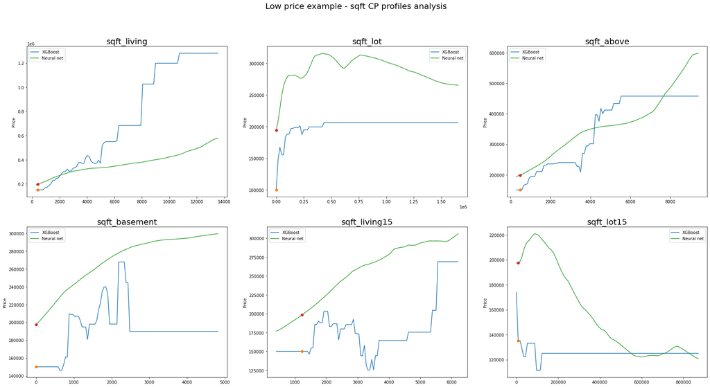

One can see here, that profiles made by the neural network are much smoother, as would be expected. The predicted price values are different, but quite often the trend is more or less the same. This goes hand in hand with the fact, that LIME decomposition (previous notebook) was very similar for both models.

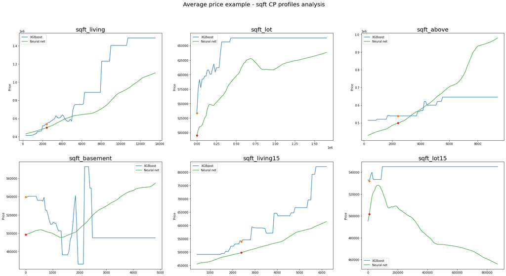

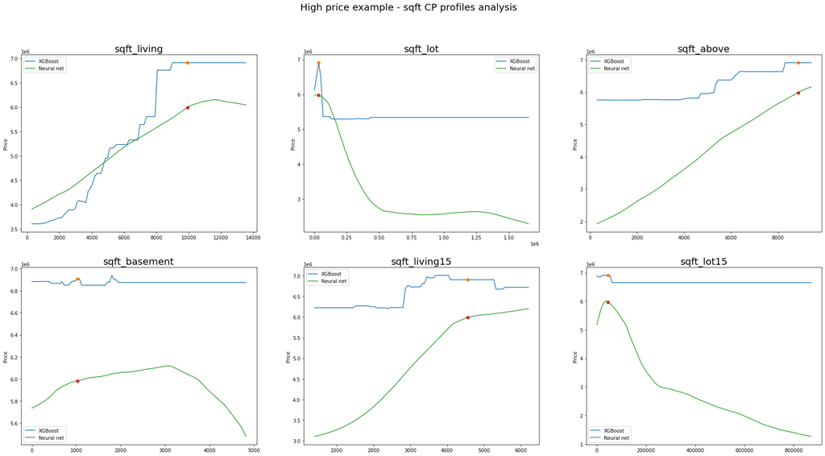

The most surprising variable to me is **sqft_lot15** (the square footage of the land lots of the nearest 15 neighbors). Firstly, it is an example of the feature whose role differs for both models. In the case of XGBoost, changing sqft_lot15 has little or no impact on the price. But in the case of neural network, the predictions *drop* significantly while increasing the sqft_lot. It is totally counter-intuitive to me. What is worse, similar behavior is observed for **sqft_lot** for the expensive example.

#### Categorical variables

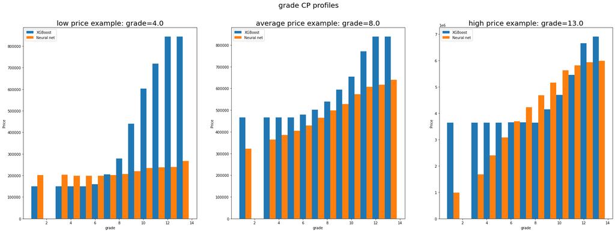

Grade was one on the most important variables for both models for LIME decomposition. But while generally increasing grade increases the price (very intuitively), I am surprised to see that for the low price example the impact of grade is almost no visible for the neural network predictions. And it is the very opposite for XGBoost.

Mentioning LIME reminds me that my LIME decomposition of these two models showed **waterfront** as the very important variable. I would like to see if its impact on the price is so visible yet again:

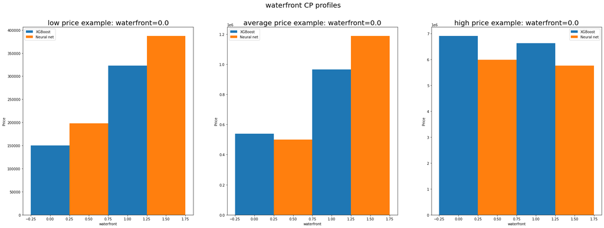

Yes, adding waterfront view doubles the price for in the case of both models for the low price and average price example. But for the high price example it lowers the price and I can't see the reason why.

Let's take a look at the remaining categorical features:

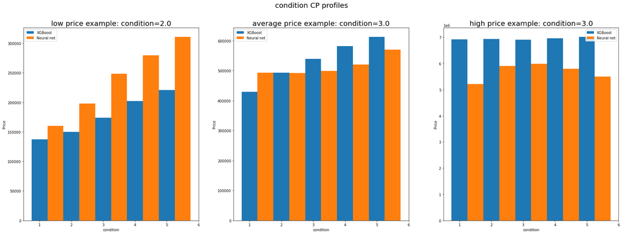

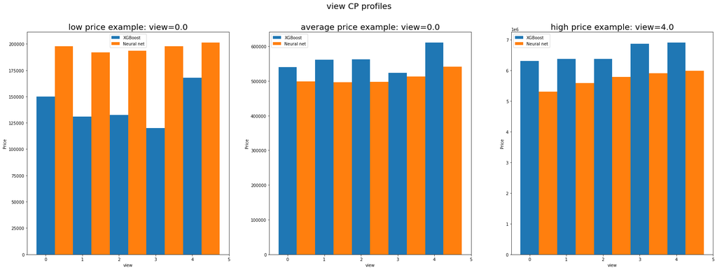

**condition** can boost the price, especially for the cheaper houses. **view** has almost no influence on the price.

I remember from my SHAP and LIME analysis, that the role of number of bedrooms, bathrooms and floors was almost no visible. Let's see if this happen for CP profiles:

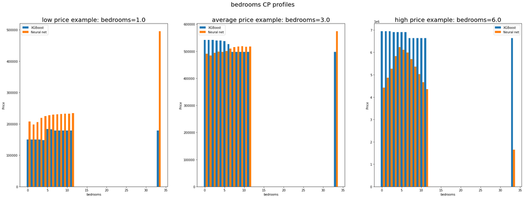

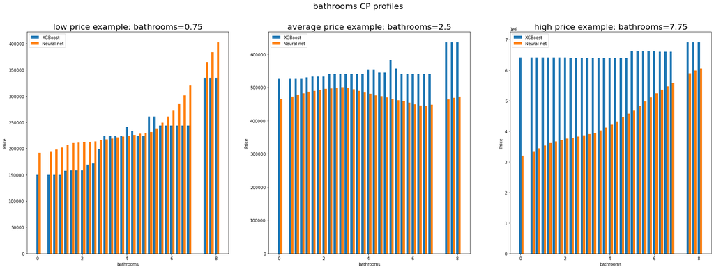

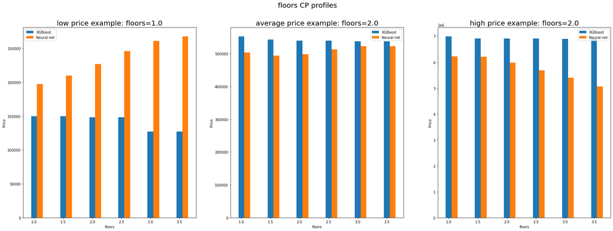

The most visible feature of these plot for me is the fact that the profiles of neural network are much more variable, while the profiles of XGBoost are more constant.

# Appendix

### Data loading and preparation

```python
import pandas as pd
import matplotlib.pyplot as plt
import numpy as np
from sklearn.model_selection import train_test_split

%matplotlib inline
```

```python
house_data = pd.read_csv("kc_house_data.csv")
house_data.head()
```

|  | id | date | price | bedrooms | bathrooms | sqft_living | sqft_lot | floors | waterfront | view | ... | grade | sqft_above | sqft_basement | yr_built | yr_renovated | zipcode | lat | long | sqft_living15 | sqft_lot15 |
| --- | --- | --- | --- | --- | --- | --- | --- | --- | --- | --- | --- | --- | --- | --- | --- | --- | --- | --- | --- | --- | --- |
| 0 | 7129300520 | 20141013T000000 | 221900.0 | 3 | 1.00 | 1180 | 5650 | 1.0 | 0 | 0 | ... | 7 | 1180 | 0 | 1955 | 0 | 98178 | 47.5112 | -122.257 | 1340 | 5650 |
| 1 | 6414100192 | 20141209T000000 | 538000.0 | 3 | 2.25 | 2570 | 7242 | 2.0 | 0 | 0 | ... | 7 | 2170 | 400 | 1951 | 1991 | 98125 | 47.7210 | -122.319 | 1690 | 7639 |
| 2 | 5631500400 | 20150225T000000 | 180000.0 | 2 | 1.00 | 770 | 10000 | 1.0 | 0 | 0 | ... | 6 | 770 | 0 | 1933 | 0 | 98028 | 47.7379 | -122.233 | 2720 | 8062 |
| 3 | 2487200875 | 20141209T000000 | 604000.0 | 4 | 3.00 | 1960 | 5000 | 1.0 | 0 | 0 | ... | 7 | 1050 | 910 | 1965 | 0 | 98136 | 47.5208 | -122.393 | 1360 | 5000 |
| 4 | 1954400510 | 20150218T000000 | 510000.0 | 3 | 2.00 | 1680 | 8080 | 1.0 | 0 | 0 | ... | 8 | 1680 | 0 | 1987 | 0 | 98074 | 47.6168 | -122.045 | 1800 | 7503 |

5 rows × 21 columns

```python
X = house_data.drop(["id", "price", "date", "zipcode"], axis = 1)
cols_idx = {}
for col in X.columns:
    cols_idx[col] = X.columns.get_loc(col)

X = X.to_numpy()
y = house_data["price"]
```

I make train test split. Becuase the range of prices is very big I do stratified split to ensure that in both datasets the ratio of cheap and expensive samples is similar.

```python
y_binned = y.apply(lambda x: round(x/1e+5) if x<2e+6 else 21)
bins = y_binned.unique().tolist()
bins.sort()

X_train, X_test, y_train, y_test = train_test_split(X, y_binned, test_size = 0.3, stratify = y_binned, random_state = 1)

# now y_train is splitted y_binned. I want y, but with indexes from splitted y_binned
y_train = y.iloc[y_train.index]
y_test = y.iloc[y_test.index]
```

### Training the model - XGBoost

I train XGBoost model with parameters I found performing well in the previous homework

```python
import xgboost

xgb_model = xgboost.XGBRegressor(colsample_bytree=0.6, eta=0.15, max_depth=5, gamma=0,
                                 objective="reg:squarederror", random_state=1)

xgb_model.fit(X_train, y_train)
```

```
XGBRegressor(base_score=0.5, booster='gbtree', colsample_bylevel=1,
             colsample_bynode=1, colsample_bytree=0.6, eta=0.15, gamma=0,
             gpu_id=-1, importance_type='gain', interaction_constraints='',
             learning_rate=0.150000006, max_delta_step=0, max_depth=5,
             min_child_weight=1, missing=nan, monotone_constraints='()',
             n_estimators=100, n_jobs=4, num_parallel_tree=1, random_state=1,
             reg_alpha=0, reg_lambda=1, scale_pos_weight=1, subsample=1,
             tree_method='exact', validate_parameters=1, verbosity=None)
```

```python
y_hat = xgb_model.predict(X_test)

# I rescale back the precises to the original values to make it possible to compare to xgboost
print(f"Mean absolute error on the test set: {abs(y_hat - y_test).mean():,.0f}$")
```

```
Mean absolute error on the test set: 68,818$
```

In the previoius notebook about SHAP I chose three different observations: one which price is *low*, one which price is around the *average* and one with very *high price*. I use the same observations in this notebook:

```python
cheap_house_idx = 465
average_house_idx = 18838
expensive_house_idx = 9254
samples = house_data.drop(["id", "date", "zipcode"], axis = 1).iloc[[cheap_house_idx, average_house_idx, expensive_house_idx]]
samples["price"] = samples["price"].map("{:,.0f}$".format)
samples = samples.set_index(pd.Index(["low price", "average price", "high price"]))
samples.head()
```

|  | price | bedrooms | bathrooms | sqft_living | sqft_lot | floors | waterfront | view | condition | grade | sqft_above | sqft_basement | yr_built | yr_renovated | lat | long | sqft_living15 | sqft_lot15 |
| --- | --- | --- | --- | --- | --- | --- | --- | --- | --- | --- | --- | --- | --- | --- | --- | --- | --- | --- |
| low price | 80,000$ | 1 | 0.75 | 430 | 5050 | 1.0 | 0 | 0 | 2 | 4 | 430 | 0 | 1912 | 0 | 47.6499 | -121.909 | 1200 | 7500 |
| average price | 540,000$ | 3 | 2.50 | 2400 | 5817 | 2.0 | 0 | 0 | 3 | 8 | 2400 | 0 | 1998 | 0 | 47.5371 | -121.870 | 2420 | 5817 |
| high price | 6,885,000$ | 6 | 7.75 | 9890 | 31374 | 2.0 | 0 | 4 | 3 | 13 | 8860 | 1030 | 2001 | 0 | 47.6305 | -122.240 | 4540 | 42730 |

For the first, cheap example, my prediction is very inaccurate. But it is decent for the remaining two exemplary observations.

### Training a second model - neural network

```python
from sklearn.preprocessing import StandardScaler

scaler = StandardScaler()
scaler.fit(X_train)
X_train_scaled = scaler.transform(X_train)
X_test_scaled = scaler.transform(X_test)

scaler_y = StandardScaler()
scaler_y.fit(y_train.to_frame())
y_train_scaled = scaler_y.transform(y_train.to_frame())
y_test_scaled = scaler_y.transform(y_test.to_frame())
```

```python
from tensorflow.keras.models import Sequential
from tensorflow.keras.layers import Dense, Dropout
from tensorflow.keras.optimizers import Adam
from keras.models import load_model

batchsize = 500
dropout_rate = 0.2
neural_net_model = Sequential([
    Dense(256, activation="relu"),
    Dropout(dropout_rate),
    Dense(256, activation="relu"),
    Dropout(dropout_rate),
    Dense(256, activation="relu"),
    Dropout(dropout_rate),
    Dense(1, activation=None),
])

neural_net_model.compile(
    loss="mean_squared_error",
    optimizer="adam"
)

neural_net_model.build(input_shape=(batchsize, X_train_scaled.shape[1]))
neural_net_model.summary()
```

```
Model: "sequential"
_________________________________________________________________
Layer (type)                 Output Shape              Param #
=================================================================
dense (Dense)                (500, 256)                4608
_________________________________________________________________
dropout (Dropout)            (500, 256)                0
_________________________________________________________________
dense_1 (Dense)              (500, 256)                65792
_________________________________________________________________
dropout_1 (Dropout)          (500, 256)                0
_________________________________________________________________
dense_2 (Dense)              (500, 256)                65792
_________________________________________________________________
dropout_2 (Dropout)          (500, 256)                0
_________________________________________________________________
dense_3 (Dense)              (500, 1)                  257
=================================================================
Total params: 136,449
Trainable params: 136,449
Non-trainable params: 0
_________________________________________________________________
```

```python
# history = neural_net_model.fit(X_train_scaled, y_train_scaled, validation_data=(X_test_scaled, y_test_scaled),
#                                batch_size=batchsize, epochs=300, verbose=0)

# plt.plot(history.history["loss"])
# plt.plot(history.history["val_loss"])
```

```python
# neural_net_model.save("neural_net_model.h5")
neural_net_model = load_model("neural_net_model.h5")
```

```python
y_hat = neural_net_model.predict(X_test_scaled)

# I rescale back the precises to the original values to make it possible to compare to xgboost
y_hat = scaler_y.inverse_transform(y_hat)
print(f"Mean absolute error on the test set: {abs(y_hat - scaler_y.inverse_transform(y_test_scaled)).mean():.0f}$")
```

```
Mean absolute error on the test set: 73075$
```

```python
y_pred_xgb = xgb_model.predict(X[[cheap_house_idx,
                                  average_house_idx,
                                  expensive_house_idx],:])

y_pred_nn = neural_net_model.predict(scaler.transform(X)[[cheap_house_idx,
                                                          average_house_idx,
                                                          expensive_house_idx], :]
                                     ).flatten()


y_pred_nn = scaler_y.inverse_transform(y_pred_nn)

y_real = y[[cheap_house_idx, average_house_idx, expensive_house_idx]]

preds = pd.DataFrame(data = {"The real price" : y_real,
                             "XGBoost prediction" : y_pred_xgb,
                             "Neural network prediction" : y_pred_nn}
                    )

preds = preds.style.format("{:,.0f}$")
preds
```

|  | The real price | XGBoost prediction | Neural network prediction |
| --- | --- | --- | --- |
| 465 | 80,000$ | 150,118$ | 197,709$ |
| 18838 | 540,000$ | 539,440$ | 498,552$ |
| 9254 | 6,885,000$ | 6,908,374$ | 5,985,286$ |

There are almost no samples in the dataset with waterfront==1. I can't understand why my models give this feature such a big role.

## Ceteris parubis on both models. Analysis of sqft columns

```python
def cp_values_num(pred_fun, X, col_idx, sample_idx, n_partitions=100):
    var_min = X[:, col_idx].min()
    var_max = X[:, col_idx].max()
    grid = np.linspace(start=var_min, stop=var_max, num=n_partitions)
    new_X = []
    for g in grid:
        new_sample = X[sample_idx,:].copy()
        new_sample[col_idx] = g
        new_X.append(new_sample)

    new_X =np.array(new_X)
    y = pred_fun(new_X)
    return y, grid
```

```python
def nn_predict(X):
    y_hat = neural_net_model.predict(scaler.transform(X))
    y_hat = scaler_y.inverse_transform(y_hat)
    return y_hat
```

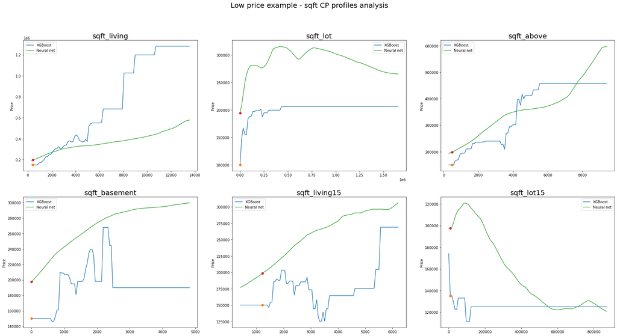

```python
sqft_var_names = ['sqft_living', 'sqft_lot', 'sqft_above', 'sqft_basement', 'sqft_living15', 'sqft_lot15']
sample_idx = cheap_house_idx

fig_sqft_cheap, axes = plt.subplots(2, 3, figsize=(30, 15))
axes = axes.flatten()
for i, var_name in enumerate(sqft_var_names):
    y_xgb, grid = cp_values_num(xgb_model.predict, X, cols_idx[var_name], sample_idx)
    actual_value = X[sample_idx, cols_idx[var_name]]
    actual_value_idx = np.argmin(np.abs(grid - actual_value))
    axes[i].plot(grid, y_xgb, label="XGBoost")
    axes[i].plot(grid[actual_value_idx], y_xgb[actual_value_idx], marker="o")

    y_nn, grid = cp_values_num(nn_predict, X, cols_idx[var_name], sample_idx)
    actual_value = X[sample_idx, cols_idx[var_name]]
    actual_value_idx = np.argmin(np.abs(grid - actual_value))
    axes[i].plot(grid, y_nn, label="Neural net")
    axes[i].plot(grid[actual_value_idx], y_nn[actual_value_idx], marker="o")

    axes[i].set_title(f"{var_name}", fontsize = 20)
    axes[i].set_ylabel(f"Price")
    axes[i].legend()

fig_sqft_cheap.suptitle("Low price example - sqft CP profiles analysis", fontsize = 20)
plt.show()
```

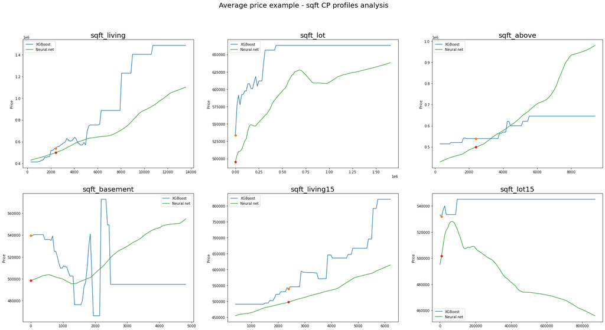

```python
sample_idx = average_house_idx

fig_sqft_average, axes = plt.subplots(2, 3, figsize=(30, 15))
axes = axes.flatten()
for i, var_name in enumerate(sqft_var_names):
    y_xgb, grid = cp_values_num(xgb_model.predict, X, cols_idx[var_name], sample_idx)
    actual_value = X[sample_idx, cols_idx[var_name]]
    actual_value_idx = np.argmin(np.abs(grid - actual_value))
    axes[i].plot(grid, y_xgb, label="XGBoost")
    axes[i].plot(grid[actual_value_idx], y_xgb[actual_value_idx], marker="o")

    y_nn, grid = cp_values_num(nn_predict, X, cols_idx[var_name], sample_idx)
    actual_value = X[sample_idx, cols_idx[var_name]]
    actual_value_idx = np.argmin(np.abs(grid - actual_value))
    axes[i].plot(grid, y_nn, label="Neural net")
    axes[i].plot(grid[actual_value_idx], y_nn[actual_value_idx], marker="o")

    axes[i].set_title(f"{var_name}", fontsize = 20)
    axes[i].set_ylabel(f"Price")
    axes[i].legend()

fig_sqft_average.suptitle("Average price example - sqft CP profiles analysis", fontsize = 20)
plt.show()
```

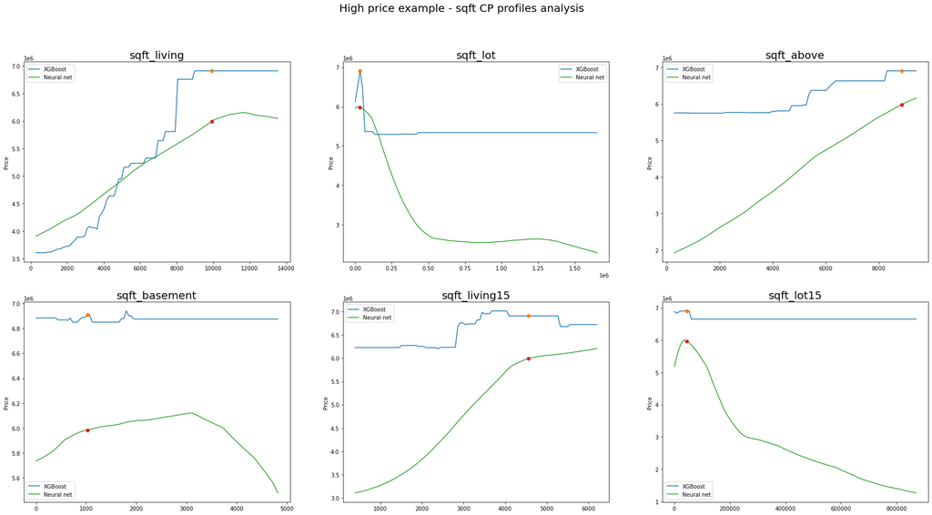

```python
sample_idx = expensive_house_idx

fig_sqft_expensive, axes = plt.subplots(2, 3, figsize=(30, 15))
axes = axes.flatten()
for i, var_name in enumerate(sqft_var_names):
    y_xgb, grid = cp_values_num(xgb_model.predict, X, cols_idx[var_name], sample_idx)
    actual_value = X[sample_idx, cols_idx[var_name]]
    actual_value_idx = np.argmin(np.abs(grid - actual_value))
    axes[i].plot(grid, y_xgb, label="XGBoost")
    axes[i].plot(grid[actual_value_idx], y_xgb[actual_value_idx], marker="o")

    y_nn, grid = cp_values_num(nn_predict, X, cols_idx[var_name], sample_idx)
    actual_value = X[sample_idx, cols_idx[var_name]]
    actual_value_idx = np.argmin(np.abs(grid - actual_value))
    axes[i].plot(grid, y_nn, label="Neural net")
    axes[i].plot(grid[actual_value_idx], y_nn[actual_value_idx], marker="o")

    axes[i].set_title(f"{var_name}", fontsize = 20)
    axes[i].set_ylabel(f"Price")
    axes[i].legend()

fig_sqft_expensive.suptitle("High price example - sqft CP profiles analysis", fontsize = 20)
plt.show()
```

## CP profiles for categorical variables

```python
def cp_values_cat(pred_fun, X, col_idx, sample_idx):

    values = np.unique(X[:, col_idx])

    new_X = []
    for v in values:
        new_sample = X[sample_idx,:].copy()
        new_sample[col_idx] = v
        new_X.append(new_sample)

    new_X =np.array(new_X)
    y = pred_fun(new_X)
    return y, values
```

```python
cols_idx
```

```
{'bedrooms': 0,
 'bathrooms': 1,
 'sqft_living': 2,
 'sqft_lot': 3,
 'floors': 4,
 'waterfront': 5,
 'view': 6,
 'condition': 7,
 'grade': 8,
 'sqft_above': 9,
 'sqft_basement': 10,
 'yr_built': 11,
 'yr_renovated': 12,
 'lat': 13,
 'long': 14,
 'sqft_living15': 15,
 'sqft_lot15': 16}
```

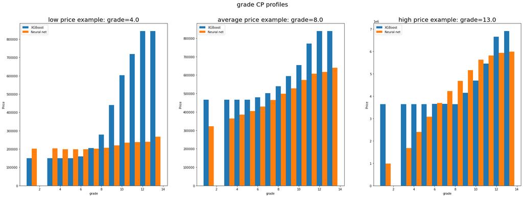

```python
samples = [cheap_house_idx, average_house_idx, expensive_house_idx]
samples_names = ["low price", "average price", "high price"]

fig_grade, axes = plt.subplots(1, 3, figsize=(30, 10))
axes = axes.flatten()
var_name = "grade"
for i, sample_idx in enumerate(samples):
    width = 0.5
    y_xgb, grid = cp_values_cat(xgb_model.predict, X, cols_idx[var_name], sample_idx)
    axes[i].bar(grid, y_xgb, width, label="XGBoost")

    y_nn, grid = cp_values_cat(nn_predict, X, cols_idx[var_name], sample_idx)
    axes[i].bar(grid+width, y_nn.flatten(), width, label="Neural net")

    axes[i].set_title(f"{samples_names[i]} example: {var_name}={X[sample_idx, cols_idx[var_name]]}", fontsize = 20)
    axes[i].set_xlabel(f"{var_name}")
    axes[i].set_ylabel(f"Price")
    axes[i].legend()

fig_grade.suptitle(f"{var_name} CP profiles", fontsize = 20)
plt.show()
```

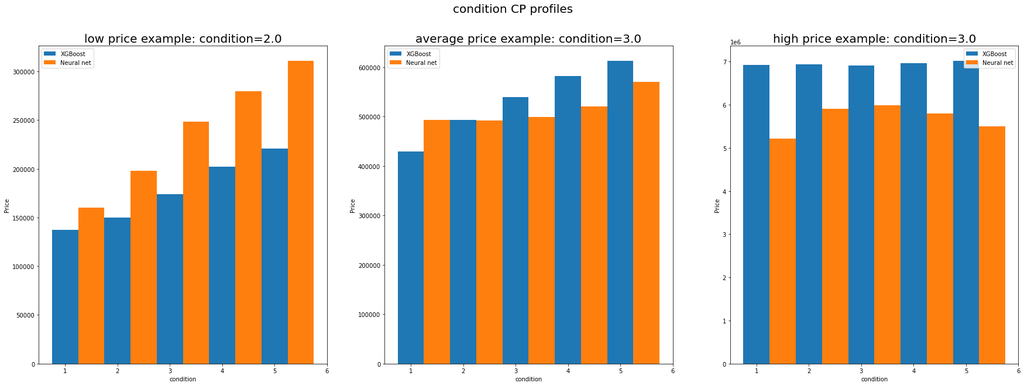

```python
samples = [cheap_house_idx, average_house_idx, expensive_house_idx]
samples_names = ["low price", "average price", "high price"]

fig_condition, axes = plt.subplots(1, 3, figsize=(30, 10))
axes = axes.flatten()
var_name = "condition"
for i, sample_idx in enumerate(samples):
    width = 0.5
    y_xgb, grid = cp_values_cat(xgb_model.predict, X, cols_idx[var_name], sample_idx)
    axes[i].bar(grid, y_xgb, width, label="XGBoost")

    y_nn, grid = cp_values_cat(nn_predict, X, cols_idx[var_name], sample_idx)
    axes[i].bar(grid+width, y_nn.flatten(), width, label="Neural net")

    axes[i].set_title(f"{samples_names[i]} example: {var_name}={X[sample_idx, cols_idx[var_name]]}", fontsize = 20)
    axes[i].set_xlabel(f"{var_name}")
    axes[i].set_ylabel(f"Price")
    axes[i].legend()

fig_condition.suptitle(f"{var_name} CP profiles", fontsize = 20)
plt.show()
```

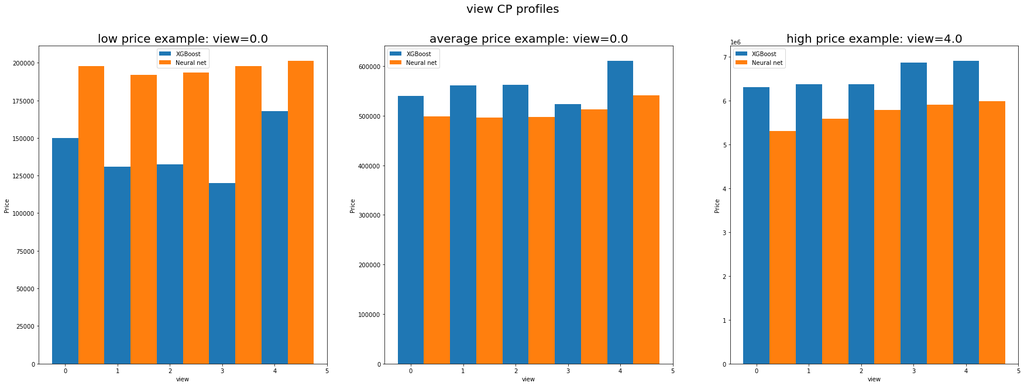

```python
samples = [cheap_house_idx, average_house_idx, expensive_house_idx]
samples_names = ["low price", "average price", "high price"]

fig_view, axes = plt.subplots(1, 3, figsize=(30, 10))
axes = axes.flatten()
var_name = "view"
for i, sample_idx in enumerate(samples):
    width = 0.5
    y_xgb, grid = cp_values_cat(xgb_model.predict, X, cols_idx[var_name], sample_idx)
    axes[i].bar(grid, y_xgb, width, label="XGBoost")

    y_nn, grid = cp_values_cat(nn_predict, X, cols_idx[var_name], sample_idx)
    axes[i].bar(grid+width, y_nn.flatten(), width, label="Neural net")

    axes[i].set_title(f"{samples_names[i]} example: {var_name}={X[sample_idx, cols_idx[var_name]]}", fontsize = 20)
    axes[i].set_xlabel(f"{var_name}")
    axes[i].set_ylabel(f"Price")
    axes[i].legend()

fig_view.suptitle(f"{var_name} CP profiles", fontsize = 20)
plt.show()
```

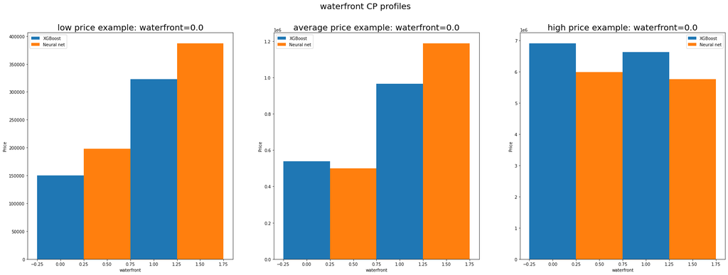

```python
samples = [cheap_house_idx, average_house_idx, expensive_house_idx]
samples_names = ["low price", "average price", "high price"]

fig_waterfront, axes = plt.subplots(1, 3, figsize=(30, 10))
axes = axes.flatten()
var_name = "waterfront"
for i, sample_idx in enumerate(samples):
    width = 0.5
    y_xgb, grid = cp_values_cat(xgb_model.predict, X, cols_idx[var_name], sample_idx)
    axes[i].bar(grid, y_xgb, width, label="XGBoost")

    y_nn, grid = cp_values_cat(nn_predict, X, cols_idx[var_name], sample_idx)
    axes[i].bar(grid+width, y_nn.flatten(), width, label="Neural net")

    axes[i].set_title(f"{samples_names[i]} example: {var_name}={X[sample_idx, cols_idx[var_name]]}", fontsize = 20)
    axes[i].set_xlabel(f"{var_name}")
    axes[i].set_ylabel(f"Price")
    axes[i].legend()

fig_waterfront.suptitle(f"{var_name} CP profiles", fontsize = 20)
plt.show()
```

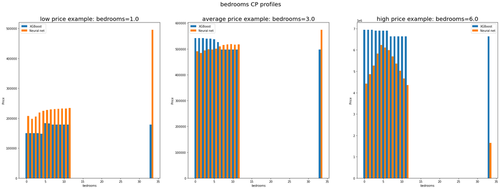

```python
fig_bedrooms, axes = plt.subplots(1, 3, figsize=(30, 10))
axes = axes.flatten()
var_name = "bedrooms"
for i, sample_idx in enumerate(samples):
    width = 0.5
    y_xgb, grid = cp_values_cat(xgb_model.predict, X, cols_idx[var_name], sample_idx)
    axes[i].bar(grid, y_xgb, width, label="XGBoost")

    y_nn, grid = cp_values_cat(nn_predict, X, cols_idx[var_name], sample_idx)
    axes[i].bar(grid+width, y_nn.flatten(), width, label="Neural net")

    axes[i].set_title(f"{samples_names[i]} example: {var_name}={X[sample_idx, cols_idx[var_name]]}", fontsize = 20)
    axes[i].set_xlabel(f"{var_name}")
    axes[i].set_ylabel(f"Price")
    axes[i].legend()

fig_bedrooms.suptitle(f"{var_name} CP profiles", fontsize = 20)
plt.show()
```

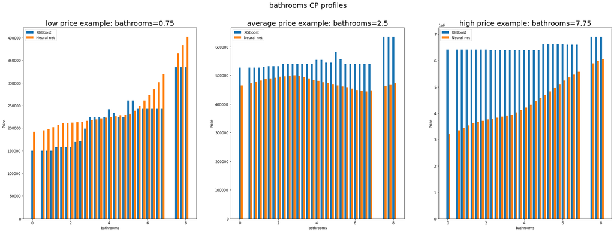

```python
fig_bathrooms, axes = plt.subplots(1, 3, figsize=(30, 10))
axes = axes.flatten()
var_name = "bathrooms"
for i, sample_idx in enumerate(samples):
    width = 0.1
    y_xgb, grid = cp_values_cat(xgb_model.predict, X, cols_idx[var_name], sample_idx)
    axes[i].bar(grid, y_xgb, width, label="XGBoost")

    y_nn, grid = cp_values_cat(nn_predict, X, cols_idx[var_name], sample_idx)
    axes[i].bar(grid+width, y_nn.flatten(), width, label="Neural net")

    axes[i].set_title(f"{samples_names[i]} example: {var_name}={X[sample_idx, cols_idx[var_name]]}", fontsize = 20)
    axes[i].set_xlabel(f"{var_name}")
    axes[i].set_ylabel(f"Price")
    axes[i].legend()

fig_bathrooms.suptitle(f"{var_name} CP profiles", fontsize = 20)
plt.show()
```

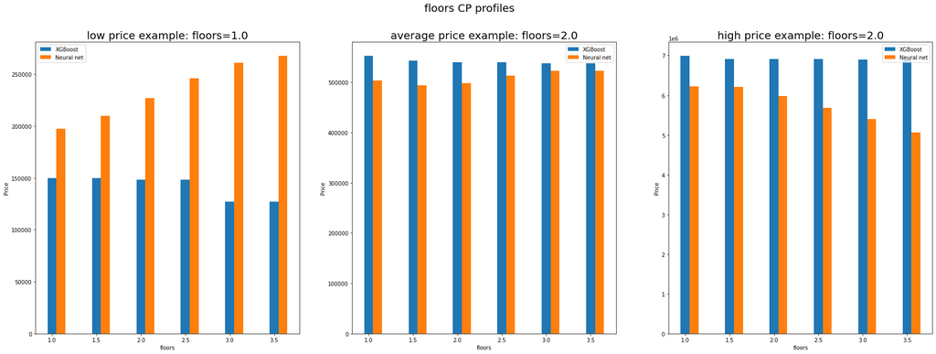

```python
fig_floors, axes = plt.subplots(1, 3, figsize=(30, 10))
axes = axes.flatten()
var_name = "floors"
for i, sample_idx in enumerate(samples):
    width = 0.1
    y_xgb, grid = cp_values_cat(xgb_model.predict, X, cols_idx[var_name], sample_idx)
    axes[i].bar(grid, y_xgb, width, label="XGBoost")

    y_nn, grid = cp_values_cat(nn_predict, X, cols_idx[var_name], sample_idx)
    axes[i].bar(grid+width, y_nn.flatten(), width, label="Neural net")

    axes[i].set_title(f"{samples_names[i]} example: {var_name}={X[sample_idx, cols_idx[var_name]]}", fontsize = 20)
    axes[i].set_xlabel(f"{var_name}")
    axes[i].set_ylabel(f"Price")
    axes[i].legend()

fig_floors.suptitle(f"{var_name} CP profiles", fontsize = 20)
plt.show()
```